# Corporacion Favorita Grocery Unit Sales Forecasting Part 2

Fannie Yuen

2017-12-11

In the second part of the analysis other libraries will be used. **reshape2()** gathers columns into rows, while **modelr()** will be used for model predictions.

```r
library(tidyverse)
library(reshape2)
library(modelr)
```

Let us load the prepared dataset after further data cleaning and choose the sample starting from Aug 1, 2016. This will cover the one year ahead period of the test set, and at the same time avoid the quantity fluctuation around Apr and May in 2016.

```r
load("data_c.Rda")
```

```r
data <- data %>%
  filter(Date>="2016-08-01")
```

As mentioned in the project plan, one of the key challenges in this task is to deal with the great number of high cardinality features. Most machine learning models do not do well in existence of highly cardinalities. Regarding to this constraint, a transformation trick is used to calculate the Average Leaving-one-out Response Rate of different values in these categorical variables. The following code shows how the categorical value *Locale_name* is transformed into the expected numerical response rate, by first getting the number of records (n) and sum of unit sales (sum) grouped by *Local_name*. These 2 columns will be attached to the data and the original value of categorical *Locale_name* will be replaced by numerical Average Leaving-one-out Response Rate.

```r
usag <- data %>%
    group_by(Locale_name) %>%
    summarize(n=n(),
              sum=sum(unit_sales))

data <- data %>%
    left_join(usag, by="Locale_name") %>%
    mutate(Locale_name=(sum-unit_sales)/(n-1)) %>%
    select(-n, -sum)
rm(usag)
```

With these numerical values, a correlation matrix can be calculated to investigate dependence among multiple variables and response variable at the same time. As a rule-of-thumb, in order to build a sound model, features should explain the response and should not highly correlated with each other to prevent multicollinearity. The follow codes show how a correlation matrix can be constructed by selected variables (id excluded) after some data cleaning.

```r
cordata <- data[, c(2, 3, 4, 5, 6, 7, 8, 9, 10, 11, 12, 13, 15, 16, 17, 18, 19, 20, 21, 22, 24, 25, 26, 27)]

cordata <- cordata %>%
  filter(!is.na(Item_nbr)) %>%
  filter(!is.na(Class))
```

To facilite the calcation of the correlation matrix, only variables and additional features from the train data are selected.

```r
cormat <- round(cor(cordata[, c(1, 2, 3, 4, 5, 6, 7, 8, 9, 10, 11, 12)]), 2)
cormat
```

After some transformation of the matrix values, correlation matrix can be visualised by using the heatmap.

```r
load("cormat_train.Rda")
get_upper_tri <- function(cormat){
  cormat[lower.tri(cormat)] <- NA
return(cormat)
}
reorder_cormat <- function(cormat){
dd <- as.dist((1-cormat)/2)
hc <- hclust(dd)
cormat <-cormat[hc$order, hc$order]
}
cormat <- reorder_cormat(cormat)
upper_tri <- get_upper_tri(cormat)
melted_cormat <- melt(upper_tri, na.rm=TRUE)
```

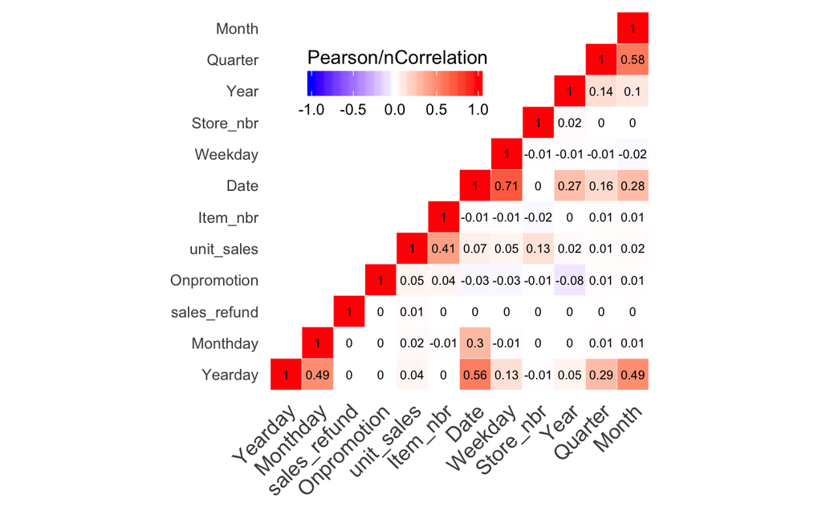

```r
ggplot(melted_cormat, aes(Var2, Var1, fill=value))+
  geom_tile(color="white")+
  scale_fill_gradient2(low="blue", high="red", mid="white",
                       midpoint=0, limit=c(-1, 1), space="Lab",
                       name="Pearson/nCorrelation")+
  theme(axis.text.x=element_text(angle=45, vjust=1, size=12, hjust=1))+
  coord_fixed()+
  geom_text(aes(Var2, Var1, label=value), color="black", size=2.5)+
  theme(
    axis.title.x = element_blank(),
    axis.title.y = element_blank(),
    panel.grid.major = element_blank(),
    panel.border = element_blank(),
    panel.background = element_blank(),
    axis.ticks = element_blank(),
    legend.justification = c(1, 0),
    legend.position = c(0.6, 0.7),
    legend.direction = "horizontal")+
  guides(fill = guide_colorbar(barwidth = 7, barheight = 1,
                               title.position = "top", title.hjust = 0.5))
```

# Model Building

Suppose all the related features together with the weight variable are chosen according to the correlation heatmap as above, the dataset is ready for building a model.

```r
colnames(cordata[, c(1, 2, 3, 4, 5, 12, 20)])
cordata <- cordata[, c(1, 2, 3, 4, 5, 12, 20)]
```

The dataset is divided into training and test set by random sampling to avoid building an overfitting model.

```r
size <- nrow(cordata)*0.6
index <- sample(1:nrow(cordata), size = size)
test <- cordata[-index,]
training <- cordata[index,]
```

### Model Specification

Let us specify the model in the following form. As suggested in the Kaggle evaluation page, no negative predictions are expected, therefore the response variable is transformed under logorithm.

```r
model <- log(unit_sales)~Date+Store_nbr+Item_nbr+Onpromotion+Weekday
```

A Generalised Linear Model (GLM) is chosen in this prediction task which allows a flexible as there is a high accumulation of quality sold around the value 0. Using linear regression model alone would ignore the 0 lower bound. Since the relationship between response and explanatory variables is not necessary in simple linear form, GLM, as an iteratively reweighted least square method using maximum likelihood estimation provides a flexible prediction solution.

### Model Selection

```r
fit_glm <- glm(model, data=training)
```

Predicted values and residuals can be added to the test set:

```r
pred_test <- test %>%
  add_predictions(fit_lm, "pred_lm") %>%
  add_residuals(fit_lm, "resid_lm")
```

### Model Evaluation

The model can finally be evaluated against the actual unit sales based on the metric [Normalized Weighted Root Mean Squared Logarithmic Error (NWRMSLE)](https://www.kaggle.com/c/favorita-grocery-sales-forecasting#evaluation):

```r
for (i in 1:nrow(pred_test)){
  sum_num <- (pred_test[i,]$weight * ((log(pred_test[i,]$pred_glm + 1) - log(pred_test[i,]$unit_sales+1))^2)) + sum_num
  i=i+1
}
```

```r
sum_de <- sum(pred_test$weight)
```

```r
NWRMSLE <- sqrt(sum_num/sum_de)
```

My latest NWRMSLE according to the above framework was 0.91, which can benchmark the error rate of estimation based on last year sales in the [Kaggle public leaderboard](https://www.kaggle.com/c/favorita-grocery-sales-forecasting/leaderboard).

# Data-driven Insights & Models for Business

Retail demand forecasting provide a foundation for product distribution and replenishment plans. A accurate (not only on current data) and good forecasting model leads to efficient production planning, customer satisfaction, cost reduction and hence sales revenue increase.

To be precise, data-mining is iterated process the to uncover promising intrinsic signals inside the data through data manipulation and transformation, summary statistics and visualisation. This will provide us insights in model building. By continuing refining features, using appropriate and efficient machine learning algorithms and adjusting model specifications, diverse models can be built and evaluated through a metric and applied to future or unseen data. If the model is proven to be good, generally accurate and stable, it can be used as basis to build for example an automatic stock replenishment system between warehouses, distributors and retail stores.

# Plan of the Project

In this Rmarkdown I present the framework to predict the quantity of items sold of an Ecuadorian grocery retailer. This project is still on-going and there are a number of areas which need further adjustments.

- Subsample Selection The current sample I use is still too large for most of the coding execution, model building and calculation. A smaller sample would be chosen for the next trial.
- Feature Engineering: As feature engineering is an ongoing process, features have to be refined after training the first model. There are some key notes in the coming plan:
- De-trend and reduce Seasonality
- Additional time features:
  - Important features: Time lag in forecasting
  - Another definition of Seasons, as Ecuador is located in the southern hemisphere, quantity demand of seasonal items like dairy products or food.
- Additional item features: most sold items per time unit, per store, and their aggregated features by item
- Additional store features: most sold stores per time unit and aggregated features by store
- Further exploration of each variables of additional features with unit price
- Abnormalities in the previous years (before 2016) should be further investigated, if the timeframe is longer in the training set
- Model Building
- Target a test error rate improvement by using different models and data
- Inclusion of cross validation set for more accurate estimation of parameters
- Use alternatives, for instance tree models and Gradient Boosting Model (GBM) as local models which deal with nonlinear transformation and interactions as well.